# Copulae and QAD

13.05.2019

## Introduction & Fundamental Definitions

## Cumulative Distribution Function

For a random variable \(X\), its cumulative distribution function (CDF) is given by:

\(F_X(x)=P(X\leq x)\)

## Cumulative Distribution Function

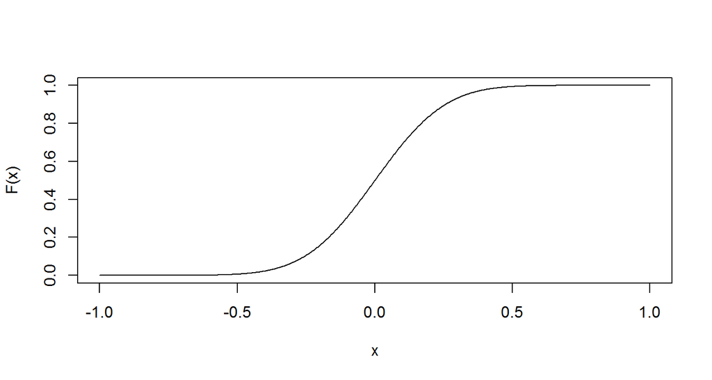

```r
x = seq(-1,1,length=1000)
y = pnorm(x,0,0.2)
plot(x, y, type="l", ylab='F(x)')
```

## Joint Cumulative Distribution

For a pair of random variables \(X,Y\) their joint cumulative distribution function is given by:

\(F_{X,Y}(x,y)=P(X\leq x, Y\leq y)\)

[figure not shown]

<sup>1</sup>https://www.mathworks.com

## Marginal Distribution

For a pair of continuous random variables \(X,Y\) with a known joint distribution, the marginal probability density function \(p_X\) can be defined as:

\(p_X(x)=\int_yp_{X,Y}(x,y)dy\)

[figure not shown]

<sup>2</sup>https://upload.wikimedia.org

## Copula

## What is a Copula?

A simple (implicit) definition of a (bivariate) copula is as follows: A copula is the joint distribution of two – on \([0,1]\) – continuous random variables, restricted to \([0,1]^2\)

This implies the following two properties, which are also used to define two-dimensional Copulae explicitly:

A copula is a function \(A:[0,1]^2 \to [0,1]\) with the following properties:

1. \(\forall u \in [0,1]: A(u,1) = A(1,u) = u, A(u,0) = A(0,u) = 0\)
2. For \(0 \leq u_1 \leq u_2 \leq 1\) and \(0 \leq v_1 \leq v_2 \leq 1\) we have: \(A(u_2,v_2) - A(u_1,v_2) - A(u_2,v_1) + A(u_1,v_1) \geq 0\)

## Examples of Copulae

- \(M(u,v) = \text{min}\{u,v\}\)
- \(W(u,v) = \text{max}\{u+v-1,0\}\)
- \(\Pi(u,v) = u \cdot v\) (product copula)

Recall: For independent random variables, the joint distribution is the product of the marginal distributions.

[figure not shown]

<sup>3</sup>https://www.mathworks.com

## Sklar’s theorem:

Let \(H\) denote the joint distribution of the random variables \(X,Y\). Furhermore, let \(X \sim F\) and \(Y \sim G\). Then, there exists a copula \(A\), such that for all \(x,y \in \mathbb{R}\) we have: \[ H(x,y) = A(F(x),G(y)) \] For continuous \(F,G\), the Copula \(A\) is unique. On the other hand, for every copula \(A\), we get a two-dimensional distribution via \(A(F,G)\).

So, (two-dimensional) copulae give us the link between two-dimensional distributions and their marginal distributions.

## Empirical Distribution Function

Given a sample \(S\) of size \(n\) of a random variable \(X\), how would we estimate the underlying distribution of \(X\)?

## Empirical Distribution Function

Given a sample \(S\) of size \(n\) of a random variable \(X\), how would we estimate the underlying distribution of \(X\)?

The Empirical Distribution Function is defined as: \[\hat F_n(x) = \frac{\#\{x_i\in S|x_i\leq x\}}{n}\]

In R, this function can be calculated via the call *ecdf(sample)*

## Empirical Copula

We can try a similar approach with copulae, since Sklar’s theorem (at least) guarantees the existence of a copula \(A_n\), i.e.

\(H_n(x,y) = A_n(F_n(x),G_n(y))\),

where \(H_n\) is the empirical joint distribution function of the sample.

However, depending on the metric used, we will not get convergence to the copula of the underlying distribution.

## Empirical Copula – Example

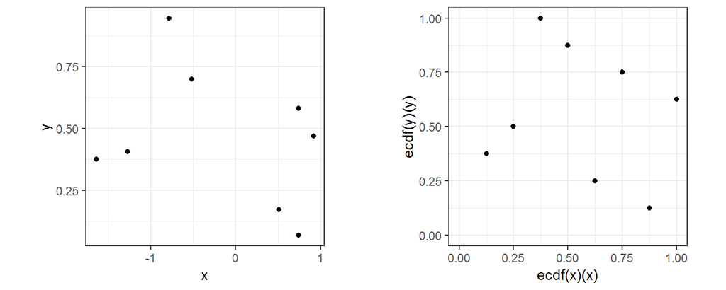

We now take any copula \(B\) and shrink it down by \(\frac{1}{n}\) – now it has the size of a single square of the grid. Then we put this shrunk \(B\) for each grid square with a pseudo–observation for its upper right corner.

## Empirical Copula – Example

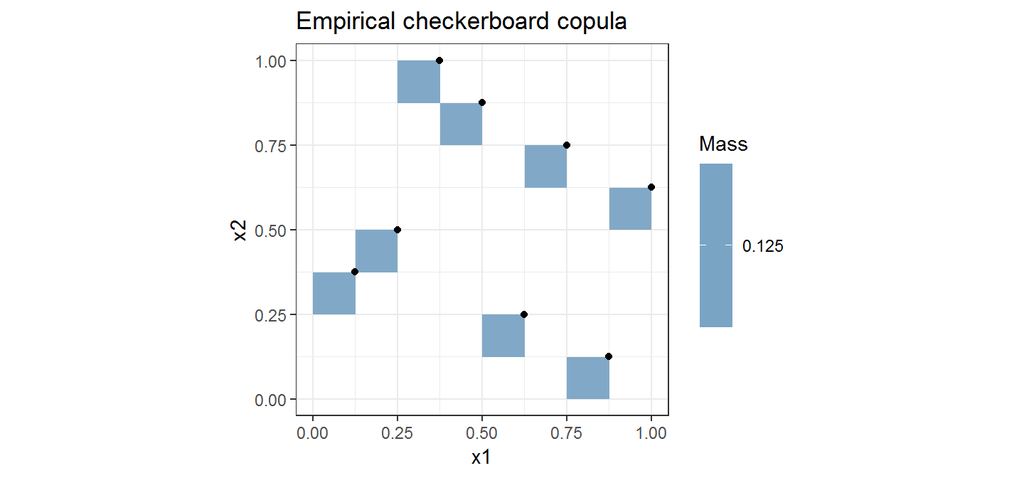

This is, how an empirical copula may look like, if we constructed it using the product copula \(\Pi\).

## Checkerbord Copulae: Motivation

Depending on the metric used, an empirical copula might not suffice to estimate the “true” one.

If we take the uniform distance \(d_\infty\), then an empirical copula \(A_n^B\) (we denote the copula \(B\) which we used to construct the empirical) of, say, the product copula \(\Pi\) may converge, i.e. \[ d_\infty(A_n^B, \Pi) = \text{max}\{|A_n^B(x,y) - \Pi(x,y)|; \; x,y \in [0,1]\} \to 0 \] as \(n \to \infty\)

## Checkerboard Copulae: Motivation

However, if we use another metric on Copulae, \(D_1\), we may be in trouble. To construct this metric, we use special markov kernels called *regular conditional distributions* like this: \[ K(X(\omega), B) = \mathbb{E}(\mathbb{1}_B \circ Y | X) \] and then define \[ D_1(A,B) := \int_{[0,1]} \int_{[0,1]} |K_A(x,[0,y]) - K_B(x,[0,y])| \;dx \; dy \] In this metric then, \(D_1(A_n^B,\Pi) \xrightarrow{n \to \infty} \frac{1}{3}\), which is bad.

## Checkerbord Copulae:

We would like to have convergence even in the \(D_1\) metric however.

One problem of empirical copulae could be, that the sample size dictates, how many squares actually have mass and that mass is always the same, \(\frac{1}{n}\cdot\text{mass of }B\) or \(0\).

What we could try to do is decoupling the fineness of the grid from the sample size (ensuring, that we still end up with a copula).

An absolutely continuous copula, which has a constant density on the interior of each square of our (refined) \(N \times N\) grid, we call \(N-\) Checkerboard Copula.

## Example

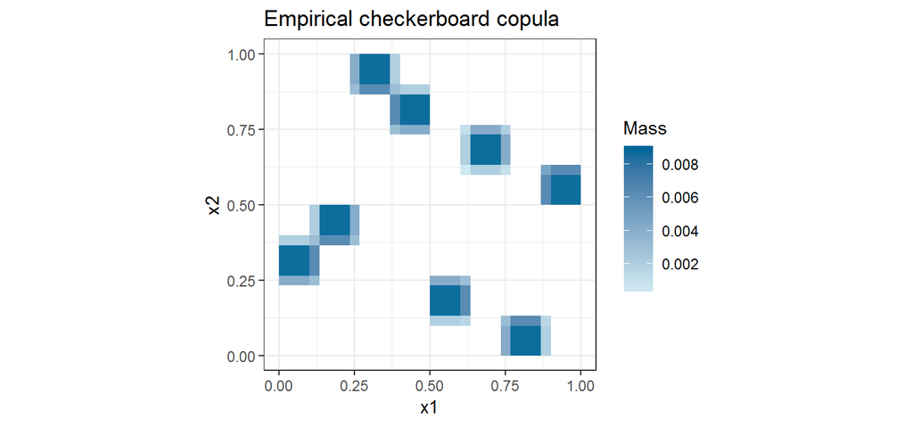

We started with the same (pseudo-) observations, but achieved smoother transitions between squares with mass / no mass.

## The Function emp_c_copula

The function emp_c_copula computes the mass-distribution of the empirical (checkerboard) copula, given a bivariate sample \((x_1,y_1),\dots,(x_n,y_n)\).

```r
#install.packages("qad")
library(qad)
```

```r
n = 15
x = rnorm(n,0,1)
y = runif(n,0,1)
df = data.frame(x,y)
emp_cop = emp_c_copula(df,smoothing = FALSE)
emp_check_cop = emp_c_copula(df,smoothing = TRUE,resolution = 20)
```

## The Function plot_density:

The function plot_density allows us to visualize copulae by plotting its density or mass distribution.

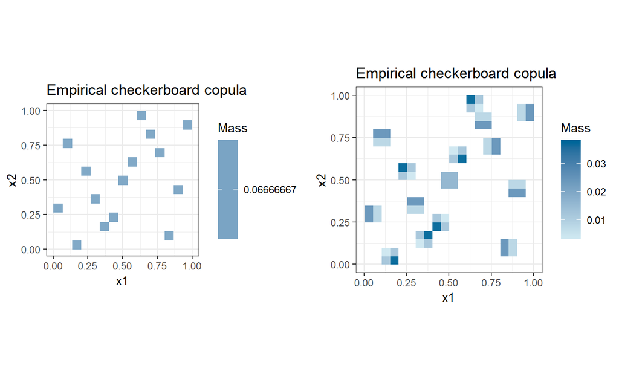

```r
plot_density(emp_cop, density=FALSE)
plot_density(emp_check_cop, density=FALSE)
```

## Exercise 1 - Empirical copula

Try to calculate the empirical copula – not the checkerboard one – while having the argument *smoothing=TRUE* on. Why does this work in this particular case?

Try to explain by also plotting the pseudo observations of your generated sample into the mass-plot (also testing your *ggplot* skill a bit here).

Also, try to explain the differences in the following plots:

```r
n=10
df = data.frame(x = rnorm(n), y = runif(n))
emp_cop = emp_c_copula(df, smoothing = FALSE)
emp_check_cop = emp_c_copula(df, smoothing = TRUE, resolution = 20)
plot_density(emp_cop, density = FALSE)
plot_density(emp_check_cop, density = FALSE)
```

## Dependence Measure \(\zeta_1\)

## Motivation

Copulae give us information of the dependency between two RVs \(X\) and \(Y\).  
If they are independent, their joint distribution is described by the product copula \(\Pi\).

On the other hand we could have complete dependence, i.e. knowing \(X\) we also know \(Y\) and vice versa.

Such a property should be reflected in the copula and we want to use this to construct a *dependency measure*.

## The \(\zeta_1\)-Measure

Based on the metric \(D_1\) such a dependency measure for a copula \(A\) can be constructed in the following way: \[ \zeta_1(A) := 3\cdot D_1(A,\Pi) \; \in [0,1] \] where \(\Pi\) is, again, the product copula.

## What do we do with that?

Now, we have a sample \((x_1,y_1), \dots, (x_n, y_n)\) and we would like to know a degree of dependency between the underlying RVs \(X\) and \(Y\).

We already know how to estimate the copula \(A\), that describes the distribution \(F_{(X,Y)}\) and that is the empirical (checkerboard) copula.

## What do we do with that?

Now we calculate the empirical checkerboard copula \(A_n\). Then we simply estimate the dependency between \(X\) and \(Y\) as \(\zeta_1(A_n)\)

It would be a bit of work to do all that by hand. Luckily there is a R-function that will help us out.

#QAD - Quantification of Asymmetric Dependence

## The qad object:

A qad object can be generated with:

```r
qad(x)
```

where \(x\) is a dataframe containing the observations of two univariate/one bivariate sample.

Interesting for us is the qad component *results*, which carries the results of the \(\zeta_1\) dependency measure.

## The qad object:

Example:

```r
n = 10
x = runif(n,-1,1)
y = abs(x)
df = data.frame(x,y)
model = qad(df, print = FALSE, permutation = TRUE, resolution = 15)
model$results
```

```
##                         coef p.values
## 1        q(x1,x2) 0.87759259     0.03
## 2        q(x2,x1) 0.85768519     0.03
## 3 mean.dependence 0.86763889     0.02
## 4 asymmetry       0.01990741     0.82
```

## Exercise 2 - qad

If we look at the output of qad, we see different scores for the degree of dependency of \(Y\) on \(X\) and vice versa.

Why could that be the case? Try to come up with an example of your own to try and explain this *interesting* bit of information.

## plot.qad

Plotting a qad objects visualizes the estimated conditional probabilities for our random variables.

We generate a qad object with low resolution and look at the plot:

```r
n = 50
x = runif(n,-1,1)
y = abs(x)
df = data.frame(x,y)
model = qad(df, print = FALSE, permutation = TRUE, resolution = 10)
```

## plot.qad

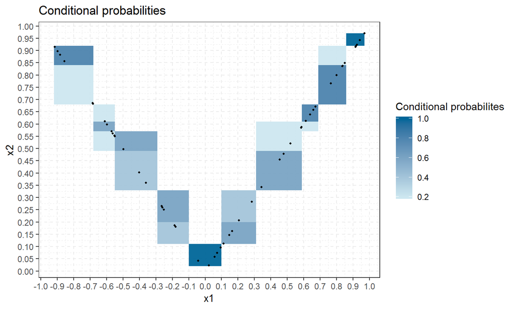

```r
plot(model, addSample = TRUE)
```

## predict.qad

```r
predict(model, values=c(0.2), conditioned = "x1", nr_intervals = 4)
```

```
##     (0.02,0.26] (0.26,0.57] (0.57,0.79] (0.79,0.97]
## 0.2         0.8         0.2           0           0
```

Here we calculate the probability that for \((x_1,x_2)\sim(X,Y)\), \(x_2\) lies in each of the intervals above, given that \(x_1\) lies in the strip that contains \(x_1=0.2\).

## Exercise 3 - plot

- Create a dummy dataset: n=100 observations of a uniformly distributed random variable and the corresponding square values.
- Create a new qad object and use the plot function to visualize the copula.
- Add the observations to the plot with the addSample parameter.
- Use the predict.qad method and sum up the probabilities for one strip (horizontal or vertical) for one value

## pairwise.qad

Now we have more than 2 RVs and are interested in their dependecies:

```r
n = 100
x = runif(n,-1,1)
y = x^3-x
z = runif(n,-1,1)
df = data.frame(x,y,z)
model = pairwise.qad(df, permutation = TRUE)
model$q
```

```
##           x         y      z
## x        NA 0.8705286 0.2565
## y 0.7978476        NA 0.2130
## z 0.1765000 0.1515000     NA
```

## heatmap.qad

We can visualize the pairwise dependencies with a heatmap:

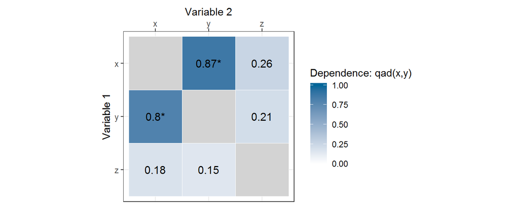

```r
heatmap.qad(model, select = "dependence",
                 significance = TRUE,
                 sign.level = 0.01)
```

## cci

We can use the qad metric to test hypothesis:

cci (conditional confidence interval) provides a confidence interval for independence (for the qad measure).

Therefore we can compare the qad-value to the interval boundaries and check if the null hypothesis of independence holds or has to be rejected.

```r
cci(100, alternative = "one.sided")
```

```
##       "0"    "0.95"
## 0.0000000 0.3312945
```

## Exercise 3 - pairwise/heatmap

- Create a sample (size = 200) with the following properties:

```r
n = 200
x = runif(n,0,1)
y1 = (x*5)-floor(x*5)
y2 = sin(10*x)
y3 = x^3
df = data.frame(y1,y2,y3)
```

- Use the pairwise and heatmap methods to visualize the dependencies in the sample
- Which pair has the highest asymmetry?

## Exercise 4 - qad

- Download the RTR-dataset

  (via load(url(“http://www.trutschnig.net/RTR.RData”)) )

  and sample 1000 observations
- Examine which columns could have interesting dependencies
- Create a qad object using the qad() method on the found columns
- Use summary.qad() to get a closer look at the object

## Ecercise 5 - qad

- Use the pairwise and heatmap methods to visualize the dependencies in the RTR data set
- Which pair has the highest asymmetry?
- What problems occur?

## The End

Thank you for your attention!